# Risk Factor Analysis

## Outcome Variable

**Outcome Variable:** pers_wasted624

## Predictor Variables

**Intervention Variable:** ever_underweight06

**Adjustment Set:**

- sex
- arm
- brthmon
- vagbrth
- single
- W_mage
- W_mhtcm
- W_mwtkg
- W_mbmi
- W_meducyrs
- W_feducyrs
- W_parity
- delta_brthmon
- delta_vagbrth
- delta_single
- delta_W_mage
- delta_W_mhtcm
- delta_W_mwtkg
- delta_W_mbmi
- delta_W_meducyrs
- delta_W_feducyrs
- delta_W_parity

## Stratifying Variables

The analysis was stratified on these variable(s):

- studyid
- country

## Data Summary

| studyid | country | ever_underweight06 | pers_wasted624 | n_cell | n | outcome_variable |
| --- | --- | --- | --- | --- | --- | --- |
| CMC-V-BCS-2002 | INDIA | 0 | 0 | 186 | 373 | pers_wasted624 |
| CMC-V-BCS-2002 | INDIA | 0 | 1 | 4 | 373 | pers_wasted624 |
| CMC-V-BCS-2002 | INDIA | 1 | 0 | 159 | 373 | pers_wasted624 |
| CMC-V-BCS-2002 | INDIA | 1 | 1 | 24 | 373 | pers_wasted624 |
| CMIN | BANGLADESH | 0 | 0 | 118 | 252 | pers_wasted624 |
| CMIN | BANGLADESH | 0 | 1 | 1 | 252 | pers_wasted624 |
| CMIN | BANGLADESH | 1 | 0 | 109 | 252 | pers_wasted624 |
| CMIN | BANGLADESH | 1 | 1 | 24 | 252 | pers_wasted624 |
| COHORTS | GUATEMALA | 0 | 0 | 731 | 1023 | pers_wasted624 |
| COHORTS | GUATEMALA | 0 | 1 | 4 | 1023 | pers_wasted624 |
| COHORTS | GUATEMALA | 1 | 0 | 251 | 1023 | pers_wasted624 |
| COHORTS | GUATEMALA | 1 | 1 | 37 | 1023 | pers_wasted624 |
| COHORTS | INDIA | 0 | 0 | 4367 | 6897 | pers_wasted624 |
| COHORTS | INDIA | 0 | 1 | 112 | 6897 | pers_wasted624 |
| COHORTS | INDIA | 1 | 0 | 1759 | 6897 | pers_wasted624 |
| COHORTS | INDIA | 1 | 1 | 659 | 6897 | pers_wasted624 |
| COHORTS | PHILIPPINES | 0 | 0 | 2080 | 2809 | pers_wasted624 |
| COHORTS | PHILIPPINES | 0 | 1 | 73 | 2809 | pers_wasted624 |
| COHORTS | PHILIPPINES | 1 | 0 | 503 | 2809 | pers_wasted624 |
| COHORTS | PHILIPPINES | 1 | 1 | 153 | 2809 | pers_wasted624 |
| CONTENT | PERU | 0 | 0 | 207 | 215 | pers_wasted624 |
| CONTENT | PERU | 0 | 1 | 0 | 215 | pers_wasted624 |
| CONTENT | PERU | 1 | 0 | 8 | 215 | pers_wasted624 |
| CONTENT | PERU | 1 | 1 | 0 | 215 | pers_wasted624 |
| EE | PAKISTAN | 0 | 0 | 101 | 374 | pers_wasted624 |
| EE | PAKISTAN | 0 | 1 | 1 | 374 | pers_wasted624 |
| EE | PAKISTAN | 1 | 0 | 224 | 374 | pers_wasted624 |
| EE | PAKISTAN | 1 | 1 | 48 | 374 | pers_wasted624 |
| GMS-Nepal | NEPAL | 0 | 0 | 302 | 590 | pers_wasted624 |
| GMS-Nepal | NEPAL | 0 | 1 | 17 | 590 | pers_wasted624 |

[output cut: 90 more lines]

The following strata were considered:

- studyid: CMC-V-BCS-2002, country: INDIA
- studyid: CMIN, country: BANGLADESH
- studyid: COHORTS, country: GUATEMALA
- studyid: COHORTS, country: INDIA
- studyid: COHORTS, country: PHILIPPINES
- studyid: CONTENT, country: PERU
- studyid: EE, country: PAKISTAN
- studyid: GMS-Nepal, country: NEPAL
- studyid: Guatemala BSC, country: GUATEMALA
- studyid: IRC, country: INDIA
- studyid: JiVitA-3, country: BANGLADESH
- studyid: JiVitA-4, country: BANGLADESH
- studyid: Keneba, country: GAMBIA
- studyid: LCNI-5, country: MALAWI
- studyid: MAL-ED, country: BANGLADESH
- studyid: MAL-ED, country: BRAZIL
- studyid: MAL-ED, country: INDIA
- studyid: MAL-ED, country: NEPAL
- studyid: MAL-ED, country: PERU
- studyid: MAL-ED, country: SOUTH AFRICA
- studyid: MAL-ED, country: TANZANIA, UNITED REPUBLIC OF
- studyid: NIH-Birth, country: BANGLADESH
- studyid: NIH-Crypto, country: BANGLADESH
- studyid: PROBIT, country: BELARUS
- studyid: PROVIDE, country: BANGLADESH
- studyid: ResPak, country: PAKISTAN
- studyid: SAS-CompFeed, country: INDIA
- studyid: SAS-FoodSuppl, country: INDIA
- studyid: TanzaniaChild2, country: TANZANIA, UNITED REPUBLIC OF
- studyid: ZVITAMBO, country: ZIMBABWE

### Dropped Strata

Some strata were dropped due to rare outcomes:

- studyid: CMC-V-BCS-2002, country: INDIA
- studyid: CMIN, country: BANGLADESH
- studyid: COHORTS, country: GUATEMALA
- studyid: CONTENT, country: PERU
- studyid: EE, country: PAKISTAN
- studyid: Guatemala BSC, country: GUATEMALA
- studyid: LCNI-5, country: MALAWI
- studyid: MAL-ED, country: BANGLADESH
- studyid: MAL-ED, country: BRAZIL
- studyid: MAL-ED, country: INDIA
- studyid: MAL-ED, country: NEPAL
- studyid: MAL-ED, country: PERU
- studyid: MAL-ED, country: SOUTH AFRICA
- studyid: MAL-ED, country: TANZANIA, UNITED REPUBLIC OF

## Methods Detail

We’re interested in the causal parameters $E[Y_a]$ for all values of $a \in \mathcal{A}$. These parameters represent the mean outcome if, possibly contrary to fact, we intervened to set all units to have $A=a$. Under the randomization and positivity assumptions, these are identified by the statistical parameters $\psi_a=E_W[E_{Y|A,W}(Y|A=a,W)]$. In addition, we’re interested in the mean of $Y$, $E[Y]$ under no intervention (the observed mean). We will estimate these parameters by using SuperLearner to fit the relevant likelihood factors – $E_{Y|A,W}(Y|A=a,W)$ and $p(A=a|W)$, and then updating our likelihood fit using a joint TMLE.

For unadjusted analyses ($W=\{\}$), initial likelihoods were estimated using Lrnr_glm to estimate the simple $E(Y|A)$ and Lrnr_mean to estimate $p(A)$. For adjusted analyses, a small library containing Lrnr_glmnet, Lrnr_xgboost, and Lrnr_mean was used.

Having estimated these parameters, we will then use the delta method to estimate relative risks and attributable risks relative to a prespecified baseline level of $A$.

[output not shown]

[output not shown]

# Results Detail

## Results Plots

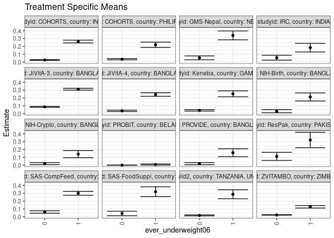

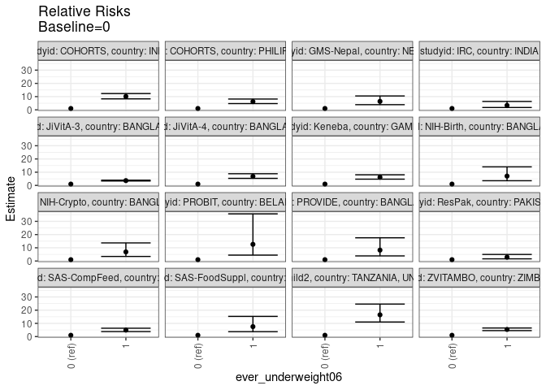

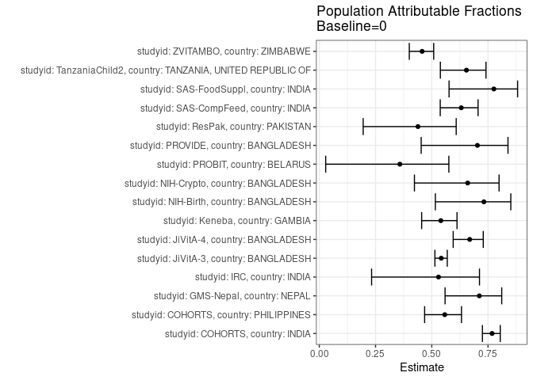

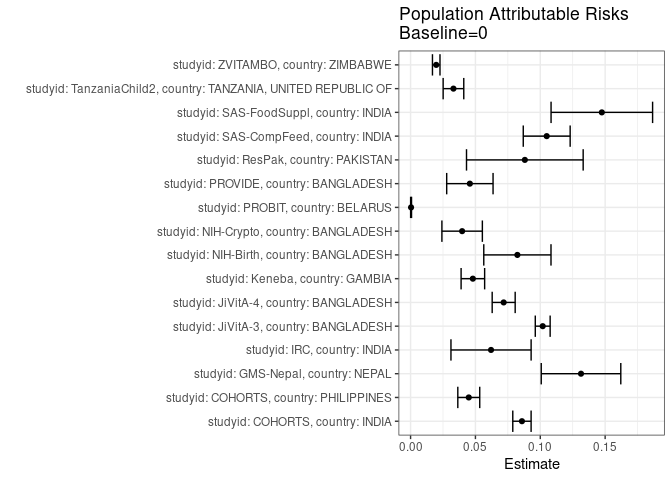

## Results Table

### Parameter: TSM

| studyid | country | intervention_level | baseline_level | estimate | ci_lower | ci_upper |
| --- | --- | --- | --- | --- | --- | --- |
| COHORTS | INDIA | 0 | NA | 0.0259300 | 0.0211279 | 0.0307321 |
| COHORTS | INDIA | 1 | NA | 0.2619338 | 0.2440389 | 0.2798288 |
| COHORTS | PHILIPPINES | 0 | NA | 0.0355906 | 0.0275147 | 0.0436666 |
| COHORTS | PHILIPPINES | 1 | NA | 0.2206729 | 0.1868482 | 0.2544976 |
| GMS-Nepal | NEPAL | 0 | NA | 0.0533473 | 0.0284650 | 0.0782296 |
| GMS-Nepal | NEPAL | 1 | NA | 0.3402684 | 0.2833919 | 0.3971449 |
| IRC | INDIA | 0 | NA | 0.0550390 | 0.0236890 | 0.0863890 |
| IRC | INDIA | 1 | NA | 0.1834539 | 0.1281548 | 0.2387530 |
| JiVitA-3 | BANGLADESH | 0 | NA | 0.0860424 | 0.0796337 | 0.0924512 |
| JiVitA-3 | BANGLADESH | 1 | NA | 0.3122618 | 0.3008289 | 0.3236947 |
| JiVitA-4 | BANGLADESH | 0 | NA | 0.0355746 | 0.0271322 | 0.0440170 |
| JiVitA-4 | BANGLADESH | 1 | NA | 0.2438586 | 0.2211295 | 0.2665877 |
| Keneba | GAMBIA | 0 | NA | 0.0408732 | 0.0320399 | 0.0497065 |
| Keneba | GAMBIA | 1 | NA | 0.2522745 | 0.2142985 | 0.2902504 |
| NIH-Birth | BANGLADESH | 0 | NA | 0.0302013 | 0.0107524 | 0.0496502 |
| NIH-Birth | BANGLADESH | 1 | NA | 0.2131148 | 0.1616847 | 0.2645448 |
| NIH-Crypto | BANGLADESH | 0 | NA | 0.0205253 | 0.0081241 | 0.0329266 |
| NIH-Crypto | BANGLADESH | 1 | NA | 0.1411140 | 0.0947808 | 0.1874471 |
| PROBIT | BELARUS | 0 | NA | 0.0006963 | 0.0002033 | 0.0011893 |
| PROBIT | BELARUS | 1 | NA | 0.0087719 | 0.0017865 | 0.0157574 |
| PROVIDE | BANGLADESH | 0 | NA | 0.0193237 | 0.0060525 | 0.0325948 |
| PROVIDE | BANGLADESH | 1 | NA | 0.1592040 | 0.1085836 | 0.2098244 |
| ResPak | PAKISTAN | 0 | NA | 0.1127626 | 0.0611476 | 0.1643776 |
| ResPak | PAKISTAN | 1 | NA | 0.3222941 | 0.2231332 | 0.4214551 |
| SAS-CompFeed | INDIA | 0 | NA | 0.0613542 | 0.0459026 | 0.0768058 |
| SAS-CompFeed | INDIA | 1 | NA | 0.3005057 | 0.2758743 | 0.3251371 |
| SAS-FoodSuppl | INDIA | 0 | NA | 0.0425532 | 0.0136640 | 0.0714424 |
| SAS-FoodSuppl | INDIA | 1 | NA | 0.3207547 | 0.2578442 | 0.3836653 |
| TanzaniaChild2 | TANZANIA, UNITED REPUBLIC OF | 0 | NA | 0.0174878 | 0.0113884 | 0.0235871 |
| TanzaniaChild2 | TANZANIA, UNITED REPUBLIC OF | 1 | NA | 0.2879618 | 0.2304794 | 0.3454443 |
| ZVITAMBO | ZIMBABWE | 0 | NA | 0.0235025 | 0.0203408 | 0.0266643 |
| ZVITAMBO | ZIMBABWE | 1 | NA | 0.1274391 | 0.1118694 | 0.1430088 |

### Parameter: E(Y)

| studyid | country | intervention_level | baseline_level | estimate | ci_lower | ci_upper |
| --- | --- | --- | --- | --- | --- | --- |
| COHORTS | INDIA | NA | NA | 0.1117877 | 0.1043506 | 0.1192249 |
| COHORTS | PHILIPPINES | NA | NA | 0.0804557 | 0.0703953 | 0.0905161 |
| GMS-Nepal | NEPAL | NA | NA | 0.1847458 | 0.1534039 | 0.2160876 |
| IRC | INDIA | NA | NA | 0.1170732 | 0.0859146 | 0.1482317 |
| JiVitA-3 | BANGLADESH | NA | NA | 0.1879125 | 0.1813641 | 0.1944608 |
| JiVitA-4 | BANGLADESH | NA | NA | 0.1073532 | 0.0971813 | 0.1175251 |
| Keneba | GAMBIA | NA | NA | 0.0888980 | 0.0776057 | 0.1001903 |
| NIH-Birth | BANGLADESH | NA | NA | 0.1125461 | 0.0859151 | 0.1391771 |
| NIH-Crypto | BANGLADESH | NA | NA | 0.0602740 | 0.0429977 | 0.0775502 |
| PROBIT | BELARUS | NA | NA | 0.0010846 | 0.0004977 | 0.0016715 |
| PROVIDE | BANGLADESH | NA | NA | 0.0650407 | 0.0455353 | 0.0845460 |
| ResPak | PAKISTAN | NA | NA | 0.2008547 | 0.1494120 | 0.2522974 |
| SAS-CompFeed | INDIA | NA | NA | 0.1663067 | 0.1478935 | 0.1847199 |
| SAS-FoodSuppl | INDIA | NA | NA | 0.1900000 | 0.1515071 | 0.2284929 |
| TanzaniaChild2 | TANZANIA, UNITED REPUBLIC OF | NA | NA | 0.0505451 | 0.0409848 | 0.0601054 |
| ZVITAMBO | ZIMBABWE | NA | NA | 0.0432772 | 0.0394419 | 0.0471125 |

### Parameter: RR

| studyid | country | intervention_level | baseline_level | estimate | ci_lower | ci_upper |
| --- | --- | --- | --- | --- | --- | --- |
| COHORTS | INDIA | 0 | 0 | 1.000000 | 1.000000 | 1.000000 |
| COHORTS | INDIA | 1 | 0 | 10.101588 | 8.293059 | 12.304516 |
| COHORTS | PHILIPPINES | 0 | 0 | 1.000000 | 1.000000 | 1.000000 |
| COHORTS | PHILIPPINES | 1 | 0 | 6.200307 | 4.717442 | 8.149290 |
| GMS-Nepal | NEPAL | 0 | 0 | 1.000000 | 1.000000 | 1.000000 |
| GMS-Nepal | NEPAL | 1 | 0 | 6.378362 | 3.885937 | 10.469420 |
| IRC | INDIA | 0 | 0 | 1.000000 | 1.000000 | 1.000000 |
| IRC | INDIA | 1 | 0 | 3.333164 | 1.751202 | 6.344205 |
| JiVitA-3 | BANGLADESH | 0 | 0 | 1.000000 | 1.000000 | 1.000000 |
| JiVitA-3 | BANGLADESH | 1 | 0 | 3.629160 | 3.346691 | 3.935470 |
| JiVitA-4 | BANGLADESH | 0 | 0 | 1.000000 | 1.000000 | 1.000000 |
| JiVitA-4 | BANGLADESH | 1 | 0 | 6.854845 | 5.325994 | 8.822560 |
| Keneba | GAMBIA | 0 | 0 | 1.000000 | 1.000000 | 1.000000 |
| Keneba | GAMBIA | 1 | 0 | 6.172123 | 4.743139 | 8.031622 |
| NIH-Birth | BANGLADESH | 0 | 0 | 1.000000 | 1.000000 | 1.000000 |
| NIH-Birth | BANGLADESH | 1 | 0 | 7.056466 | 3.547479 | 14.036366 |
| NIH-Crypto | BANGLADESH | 0 | 0 | 1.000000 | 1.000000 | 1.000000 |
| NIH-Crypto | BANGLADESH | 1 | 0 | 6.875108 | 3.455870 | 13.677343 |
| PROBIT | BELARUS | 0 | 0 | 1.000000 | 1.000000 | 1.000000 |
| PROBIT | BELARUS | 1 | 0 | 12.598086 | 4.450502 | 35.661544 |
| PROVIDE | BANGLADESH | 0 | 0 | 1.000000 | 1.000000 | 1.000000 |
| PROVIDE | BANGLADESH | 1 | 0 | 8.238806 | 3.865305 | 17.560819 |
| ResPak | PAKISTAN | 0 | 0 | 1.000000 | 1.000000 | 1.000000 |
| ResPak | PAKISTAN | 1 | 0 | 2.858165 | 1.643110 | 4.971733 |
| SAS-CompFeed | INDIA | 0 | 0 | 1.000000 | 1.000000 | 1.000000 |
| SAS-CompFeed | INDIA | 1 | 0 | 4.897885 | 3.789244 | 6.330886 |
| SAS-FoodSuppl | INDIA | 0 | 0 | 1.000000 | 1.000000 | 1.000000 |
| SAS-FoodSuppl | INDIA | 1 | 0 | 7.537736 | 3.718280 | 15.280578 |
| TanzaniaChild2 | TANZANIA, UNITED REPUBLIC OF | 0 | 0 | 1.000000 | 1.000000 | 1.000000 |
| TanzaniaChild2 | TANZANIA, UNITED REPUBLIC OF | 1 | 0 | 16.466476 | 11.017361 | 24.610687 |
| ZVITAMBO | ZIMBABWE | 0 | 0 | 1.000000 | 1.000000 | 1.000000 |
| ZVITAMBO | ZIMBABWE | 1 | 0 | 5.422353 | 4.521987 | 6.501991 |

### Parameter: PAR

| studyid | country | intervention_level | baseline_level | estimate | ci_lower | ci_upper |
| --- | --- | --- | --- | --- | --- | --- |
| COHORTS | INDIA | 0 | NA | 0.0858578 | 0.0787929 | 0.0929226 |
| COHORTS | PHILIPPINES | 0 | NA | 0.0448650 | 0.0364144 | 0.0533157 |
| GMS-Nepal | NEPAL | 0 | NA | 0.1313985 | 0.1007343 | 0.1620626 |
| IRC | INDIA | 0 | NA | 0.0620342 | 0.0311334 | 0.0929351 |
| JiVitA-3 | BANGLADESH | 0 | NA | 0.1018700 | 0.0961418 | 0.1075982 |
| JiVitA-4 | BANGLADESH | 0 | NA | 0.0717786 | 0.0629143 | 0.0806429 |
| Keneba | GAMBIA | 0 | NA | 0.0480248 | 0.0389516 | 0.0570980 |
| NIH-Birth | BANGLADESH | 0 | NA | 0.0823448 | 0.0564310 | 0.1082586 |
| NIH-Crypto | BANGLADESH | 0 | NA | 0.0397486 | 0.0241519 | 0.0553453 |
| PROBIT | BELARUS | 0 | NA | 0.0003883 | 0.0000456 | 0.0007310 |
| PROVIDE | BANGLADESH | 0 | NA | 0.0457170 | 0.0278436 | 0.0635904 |
| ResPak | PAKISTAN | 0 | NA | 0.0880921 | 0.0431228 | 0.1330614 |
| SAS-CompFeed | INDIA | 0 | NA | 0.1049525 | 0.0868769 | 0.1230281 |
| SAS-FoodSuppl | INDIA | 0 | NA | 0.1474468 | 0.1083088 | 0.1865848 |
| TanzaniaChild2 | TANZANIA, UNITED REPUBLIC OF | 0 | NA | 0.0330573 | 0.0251070 | 0.0410076 |
| ZVITAMBO | ZIMBABWE | 0 | NA | 0.0197747 | 0.0168733 | 0.0226761 |

### Parameter: PAF

| studyid | country | intervention_level | baseline_level | estimate | ci_lower | ci_upper |
| --- | --- | --- | --- | --- | --- | --- |
| COHORTS | INDIA | 0 | NA | 0.7680428 | 0.7250556 | 0.8043090 |
| COHORTS | PHILIPPINES | 0 | NA | 0.5576367 | 0.4681487 | 0.6320677 |
| GMS-Nepal | NEPAL | 0 | NA | 0.7112394 | 0.5590318 | 0.8109100 |
| IRC | INDIA | 0 | NA | 0.5298756 | 0.2324793 | 0.7120378 |
| JiVitA-3 | BANGLADESH | 0 | NA | 0.5421142 | 0.5138036 | 0.5687764 |
| JiVitA-4 | BANGLADESH | 0 | NA | 0.6686208 | 0.5951352 | 0.7287682 |
| Keneba | GAMBIA | 0 | NA | 0.5402235 | 0.4549777 | 0.6121362 |
| NIH-Birth | BANGLADESH | 0 | NA | 0.7316536 | 0.5158152 | 0.8512763 |
| NIH-Crypto | BANGLADESH | 0 | NA | 0.6594659 | 0.4228966 | 0.7990594 |
| PROBIT | BELARUS | 0 | NA | 0.3580200 | 0.0283979 | 0.5758157 |
| PROVIDE | BANGLADESH | 0 | NA | 0.7028986 | 0.4528294 | 0.8386805 |
| ResPak | PAKISTAN | 0 | NA | 0.4385862 | 0.1949374 | 0.6084957 |
| SAS-CompFeed | INDIA | 0 | NA | 0.6310781 | 0.5375272 | 0.7057051 |
| SAS-FoodSuppl | INDIA | 0 | NA | 0.7760358 | 0.5768128 | 0.8814710 |
| TanzaniaChild2 | TANZANIA, UNITED REPUBLIC OF | 0 | NA | 0.6540166 | 0.5381455 | 0.7408177 |
| ZVITAMBO | ZIMBABWE | 0 | NA | 0.4569304 | 0.4000015 | 0.5084579 |